# PSTAT131_FinalProject

Immad Ali

# Introduction

## What is League of Legends?

League of Legends (LoL) is a fast paced, multiplier online battle arena styled game in which two teams of five fight against each other and destroy the enemies base. At the heart of each team is the Nexus. Destroying the enemies Nexus results in you winning the game. The map, known as Summoner’s Rift, consists of a roughly square map with each team in a corner. The map is perfectly symmetrical and consists of three lanes: top, middle, and bottom. There is also a jungle space between each lane. Players also level up their champions by gaining experience. Experience is gained by killing minions, killing enemies, or other neutral enemies on the map. In order to win the game, you’re team must progress against the enemy’s turrets, which defend the enemy nexus. The team that successful defeats the other teams Nexus, wins.

```r
library(vembedr)
embed_youtube("BGtROJeMPeE")
```

[video not shown]

## Data Source

The data I am using is from the first 10 minutes of a LoL Ranked game in the Diamond Rank. I found the data set posted on Kaggle by the user Michel’s Fanboi (who now goes by Yi Lan Ma). https://www.kaggle.com/datasets/bobbyscience/league-of-legends-diamond-ranked-games-10-min

# Data Overview

## Processing the Data

- In this step, I will go ahead and read the CSV file in and check the first 6 rows of the data set.

```r
data <- read.csv("high_diamond_ranked_10min.csv")
head(data)
```

```
##       gameId blueWins blueWardsPlaced blueWardsDestroyed blueFirstBlood
## 1 4519157822        0              28                  2              1
## 2 4523371949        0              12                  1              0
## 3 4521474530        0              15                  0              0
## 4 4524384067        0              43                  1              0
## 5 4436033771        0              75                  4              0
## 6 4475365709        1              18                  0              0
##   blueKills blueDeaths blueAssists blueEliteMonsters blueDragons blueHeralds
## 1         9          6          11                 0           0           0
## 2         5          5           5                 0           0           0
## 3         7         11           4                 1           1           0
## 4         4          5           5                 1           0           1
## 5         6          6           6                 0           0           0
## 6         5          3           6                 1           1           0
##   blueTowersDestroyed blueTotalGold blueAvgLevel blueTotalExperience
```

[output cut: 55 more lines]

- As we can see, the data has 9,879 observations and has 40 columns. One of those columns is the gameID, which is not helpful to our model. We will go ahead and remove that column from the data set. We will also go ahead and check for any missing values.

```r
# I go ahead and select the Columns of data from 2 to 40, thus excluding the gameID.
data <- data[, 2:40]

# Check if there is any missing data.
colSums(is.na(data))
```

```
##                     blueWins              blueWardsPlaced
##                            0                            0
##           blueWardsDestroyed               blueFirstBlood
##                            0                            0
##                    blueKills                   blueDeaths
##                            0                            0
##                  blueAssists            blueEliteMonsters
##                            0                            0
##                  blueDragons                  blueHeralds
##                            0                            0
##          blueTowersDestroyed                blueTotalGold
##                            0                            0
##                 blueAvgLevel          blueTotalExperience
##                            0                            0
##       blueTotalMinionsKilled blueTotalJungleMinionsKilled
##                            0                            0
##                 blueGoldDiff           blueExperienceDiff
##                            0                            0
##                 blueCSPerMin               blueGoldPerMin
##                            0                            0
##               redWardsPlaced            redWardsDestroyed
##                            0                            0
##                redFirstBlood                     redKills
##                            0                            0
##                    redDeaths                   redAssists
##                            0                            0
##             redEliteMonsters                   redDragons
##                            0                            0
##                   redHeralds           redTowersDestroyed
##                            0                            0
##                 redTotalGold                  redAvgLevel
##                            0                            0
##           redTotalExperience        redTotalMinionsKilled
##                            0                            0
##  redTotalJungleMinionsKilled                  redGoldDiff
##                            0                            0
##            redExperienceDiff                  redCSPerMin
##                            0                            0
##                redGoldPerMin
##                            0
```

- There is no missing data in our dataset. I had also addressed the issue of missing data in my data memo. Since the original data set had the gameID, I could go back and manually fill in the missing data, as long as it wasn’t to many.
- I was curious about some statistics for the predictors. I went ahead and used the summary function to look at the overall statistics of each predictor.

```r
summary(data)
```

```
##     blueWins     blueWardsPlaced  blueWardsDestroyed blueFirstBlood
##  Min.   :0.000   Min.   :  5.00   Min.   : 0.000     Min.   :0.0000
##  1st Qu.:0.000   1st Qu.: 14.00   1st Qu.: 1.000     1st Qu.:0.0000
##  Median :0.000   Median : 16.00   Median : 3.000     Median :1.0000
##  Mean   :0.499   Mean   : 22.29   Mean   : 2.825     Mean   :0.5048
##  3rd Qu.:1.000   3rd Qu.: 20.00   3rd Qu.: 4.000     3rd Qu.:1.0000
##  Max.   :1.000   Max.   :250.00   Max.   :27.000     Max.   :1.0000
##    blueKills        blueDeaths      blueAssists     blueEliteMonsters
##  Min.   : 0.000   Min.   : 0.000   Min.   : 0.000   Min.   :0.00
##  1st Qu.: 4.000   1st Qu.: 4.000   1st Qu.: 4.000   1st Qu.:0.00
##  Median : 6.000   Median : 6.000   Median : 6.000   Median :0.00
##  Mean   : 6.184   Mean   : 6.138   Mean   : 6.645   Mean   :0.55
##  3rd Qu.: 8.000   3rd Qu.: 8.000   3rd Qu.: 9.000   3rd Qu.:1.00
##  Max.   :22.000   Max.   :22.000   Max.   :29.000   Max.   :2.00
##   blueDragons     blueHeralds    blueTowersDestroyed blueTotalGold
##  Min.   :0.000   Min.   :0.000   Min.   :0.00000     Min.   :10730
##  1st Qu.:0.000   1st Qu.:0.000   1st Qu.:0.00000     1st Qu.:15416
##  Median :0.000   Median :0.000   Median :0.00000     Median :16398
##  Mean   :0.362   Mean   :0.188   Mean   :0.05142     Mean   :16503
##  3rd Qu.:1.000   3rd Qu.:0.000   3rd Qu.:0.00000     3rd Qu.:17459
##  Max.   :1.000   Max.   :1.000   Max.   :4.00000     Max.   :23701
##   blueAvgLevel   blueTotalExperience blueTotalMinionsKilled
##  Min.   :4.600   Min.   :10098       Min.   : 90.0
##  1st Qu.:6.800   1st Qu.:17168       1st Qu.:202.0
##  Median :7.000   Median :17951       Median :218.0
##  Mean   :6.916   Mean   :17928       Mean   :216.7
##  3rd Qu.:7.200   3rd Qu.:18724       3rd Qu.:232.0
##  Max.   :8.000   Max.   :22224       Max.   :283.0
##  blueTotalJungleMinionsKilled  blueGoldDiff       blueExperienceDiff
##  Min.   : 0.00                Min.   :-10830.00   Min.   :-9333.00
##  1st Qu.:44.00                1st Qu.: -1585.50   1st Qu.:-1290.50
##  Median :50.00                Median :    14.00   Median :  -28.00
##  Mean   :50.51                Mean   :    14.41   Mean   :  -33.62
##  3rd Qu.:56.00                3rd Qu.:  1596.00   3rd Qu.: 1212.00
##  Max.   :92.00                Max.   : 11467.00   Max.   : 8348.00
##   blueCSPerMin   blueGoldPerMin redWardsPlaced   redWardsDestroyed
##  Min.   : 9.00   Min.   :1073   Min.   :  6.00   Min.   : 0.000
##  1st Qu.:20.20   1st Qu.:1542   1st Qu.: 14.00   1st Qu.: 1.000
##  Median :21.80   Median :1640   Median : 16.00   Median : 2.000
##  Mean   :21.67   Mean   :1650   Mean   : 22.37   Mean   : 2.723
```

[output cut: 22 more lines]

```
##  Max.   :22732   Max.   :8.200   Max.   :22269      Max.   :289.0
##  redTotalJungleMinionsKilled  redGoldDiff        redExperienceDiff
##  Min.   : 4.00               Min.   :-11467.00   Min.   :-8348.00
##  1st Qu.:44.00               1st Qu.: -1596.00   1st Qu.:-1212.00
##  Median :51.00               Median :   -14.00   Median :   28.00
##  Mean   :51.31               Mean   :   -14.41   Mean   :   33.62
##  3rd Qu.:57.00               3rd Qu.:  1585.50   3rd Qu.: 1290.50
##  Max.   :92.00               Max.   : 10830.00   Max.   : 9333.00
##   redCSPerMin    redGoldPerMin
##  Min.   :10.70   Min.   :1121
##  1st Qu.:20.30   1st Qu.:1543
##  Median :21.80   Median :1638
##  Mean   :21.73   Mean   :1649
##  3rd Qu.:23.30   3rd Qu.:1742
##  Max.   :28.90   Max.   :2273
```

# Exploratory Data Analysis

## Win Loss Bar graph

- I decided to do a simple bar graph just to explore how the blue team was split in terms of wins versus losses.

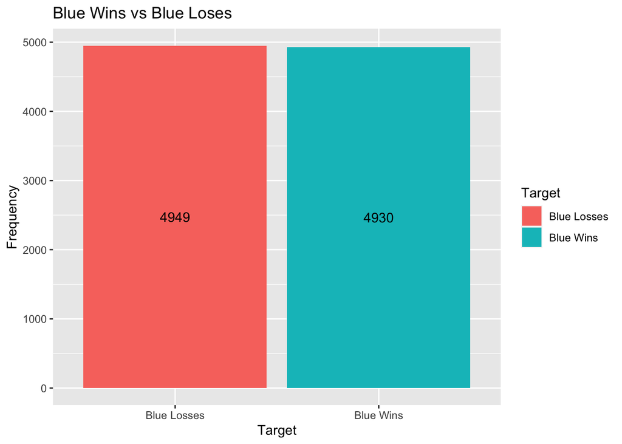

```r
#Makes the data set into a dataframe.
data_temp <- as.data.frame(table(data$blueWins))
#Names the X and Y Axis
colnames(data_temp) <- c("Target", "Frequency")
#I use this line of code to specify that I am targeting the blue wins columm.
data_temp$Target <- as.character(data_temp$Target)
# And then I target the code if the datapoint is a 0 or 1.
data_temp$Target[data_temp$Target == "0"] <- "Blue Losses"
data_temp$Target[data_temp$Target == "1"] <- "Blue Wins"

# ggplot of Blue Wins vs Blue Loses
ggplot(data = data_temp,
       mapping = aes(x = Target,
                     y = Frequency,
                     fill = Target)) +
  geom_bar(stat="identity", position = "dodge") +
  geom_text(aes(label = round(Frequency, 2)),
  position = position_stack(vjust = 0.5)) +
  labs(title = "Blue Wins vs Blue Loses")
```

- As we can see from the bar graph above, the data seems to be split 50/50 in terms of how many games the blue team won and how many they lost. We will need to dig more in depth if we want to find out what predictors have the biggest impact on blue team winning the game.

## Boxplot Red Minions Killed versus Blue Minions Killed

- To get a deeper look into the initial data set, I used a box plot to show the overall distribution of the red team and blue team minons killed.
- I wanted to get a deeper look into this because the main source of gold in this game comes from the minions killed. Therefore, we would be able to see correlations in terms how many minions were killed to the teams respective over all gold.

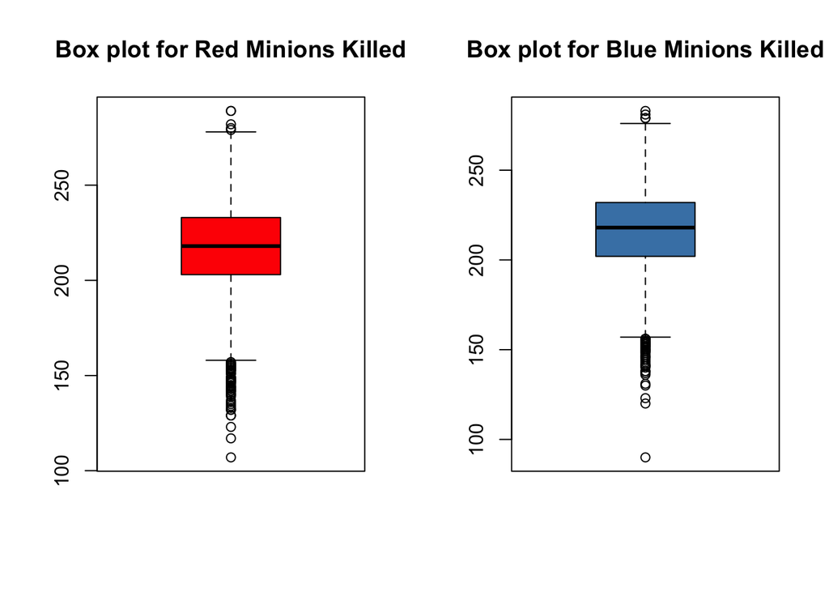

```r
par(mfrow=c(1,2))
# Makes a box plot of red minions killed
boxplot(data$redTotalMinionsKilled,
        main = "Box plot for Red Minions Killed",
        col = "red")

# Makes a Box plot of blue minions killed
boxplot(data$blueTotalMinionsKilled,
        main = "Box plot for Blue Minions Killed",
        col = "steel blue")
```

## Correlation Map of Blue Team Predictors

- I decided to make a blue team predictors correlation map to better visualize what certain predictors helped the blue team win.

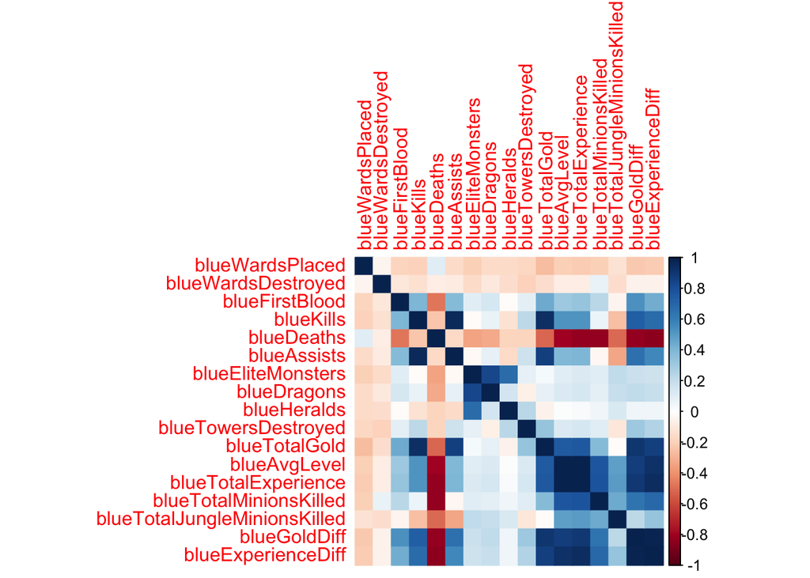

```r
# Stores the correlation map after being rounded.
M <- cor(res)

# Prints the correlation map
corrplot(M, method = "color", number.cex=0.75)
```

## Histogram of Blue Wins vs Losses including Number of Kills

- As I mentioned above, I wanted to look a bit more indepth in the total gold for blue team and the total kills for blue team.

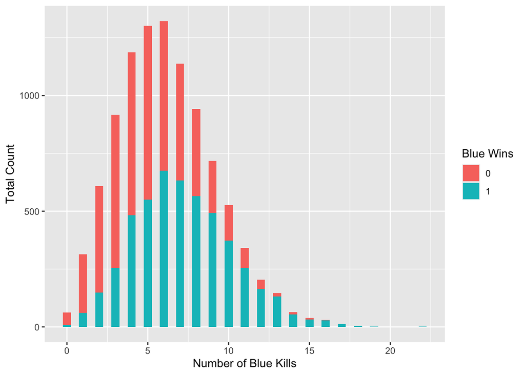

```r
options(scipen=10000)
#Total kills effect on wins
ggplot(data, aes(x = blueKills, fill = factor(blueWins))) +
  stat_count(width = 0.5) +
  xlab("Number of Blue Kills") +
  ylab("Total Count") +
  labs(fill = "Blue Wins")
```

- Looking at our histogram, we can see that as the number of kills blue team acquired, the more likely they were to win the game.

# Splitting Data and Cross Fold Validation

- In this step, I go ahead and split the original data set into a training and test set. I went ahead and chose a 70-30 split of the data. I also checked the dimensions of the test and training set to insure the they added up to the total observations.

```r
set.seed(123)
data$blueWins <- as.factor(data$blueWins)
split1<- sample(c(rep(0, 0.7 * nrow(data)), rep(1, 0.3 * nrow(data))))
train <- data[split1 == 0, ]
test <- data[split1== 1, ]
dim(train)
```

```
## [1] 6916   39
```

```r
dim(test)
```

```
## [1] 2963   39
```

- In the training set, there are 6916 observations and in the testing set, there are 2963 observations.

# Fitting the Models

## Logisitc Model

- Here I go ahead and fit the logistics regression model to our data. I also cross-validate the data.

```r
# Cross validating the data with 5 folds.
control <- trainControl(method = "cv",
                        number = 5)

# Here I go ahead and train the model to use the GLM engine.
kfold_model_glm <- train(blueWins ~.,
                     data = train,
                     trControl = control,
                     method = "glm")
# Printing out the Logistic Regression model Results.
print(kfold_model_glm)
```

```
## Generalized Linear Model
##
## 6916 samples
##   38 predictor
##    2 classes: '0', '1'
##
## No pre-processing
## Resampling: Cross-Validated (5 fold)
## Summary of sample sizes: 5533, 5533, 5533, 5533, 5532
## Resampling results:
##
##   Accuracy   Kappa
##   0.7323618  0.4647228
```

## Random Forest Model

```r
# Cross validating the data with 5 folds.
control <- trainControl(method = "cv", number = 5)

# Tuning model based on metric, mtry
metric <- "Accuracy"
# I set mtry to 38, because we have 38 predictors
mtry <- 38
tunegrid <- expand.grid(.mtry=mtry)

# Fit the Random Forest model to the data.
rf_default <- train(blueWins~., data=train, method="rf", metric=metric, tuneGrid=tunegrid, trControl=control)

#prints out the RF model results.
print(rf_default)
```

```
## Random Forest
##
## 6916 samples
##   38 predictor
##    2 classes: '0', '1'
##
## No pre-processing
## Resampling: Cross-Validated (5 fold)
## Summary of sample sizes: 5533, 5533, 5533, 5532, 5533
## Resampling results:
##
##   Accuracy   Kappa
##   0.7129852  0.4259797
##
## Tuning parameter 'mtry' was held constant at a value of 38
```

## Boosting Model

```r
# Prints out the boosting model results.
print(kfold_model_boosting)
```

```
## Stochastic Gradient Boosting
##
## 6916 samples
##   38 predictor
##    2 classes: '0', '1'
##
## No pre-processing
## Resampling: Cross-Validated (5 fold)
## Summary of sample sizes: 5533, 5533, 5532, 5533, 5533
## Resampling results across tuning parameters:
##
##   interaction.depth  n.trees  Accuracy   Kappa
##   1                   50      0.7283079  0.4566357
##   1                  100      0.7252725  0.4505502
##   1                  150      0.7254169  0.4508354
##   2                   50      0.7270074  0.4540047
##   2                  100      0.7229588  0.4459260
##   2                  150      0.7226700  0.4453456
##   3                   50      0.7239713  0.4479352
##   3                  100      0.7183324  0.4366718
##   3                  150      0.7174656  0.4349311
##
## Tuning parameter 'shrinkage' was held constant at a value of 0.1
##
## Tuning parameter 'n.minobsinnode' was held constant at a value of 10
## Accuracy was used to select the optimal model using the largest value.
## The final values used for the model were n.trees = 50, interaction.depth =
##  1, shrinkage = 0.1 and n.minobsinnode = 10.
```

## K Nearest Neighbour Model

```r
# Cross validating the data with 5 folds.
control <- trainControl(method = "cv",
                        number = 5)

# Fitting the K Neearest Neighbour model to the data set.
kfold_model_knn <- train(blueWins ~.,
                     data = train,
                     trControl = control,
                     method = "knn")

# Prints out the K Nearest Neighbor Model results
print(kfold_model_knn)
```

```
## k-Nearest Neighbors
##
## 6916 samples
##   38 predictor
##    2 classes: '0', '1'
##
## No pre-processing
## Resampling: Cross-Validated (5 fold)
## Summary of sample sizes: 5533, 5532, 5533, 5533, 5533
## Resampling results across tuning parameters:
##
##   k  Accuracy   Kappa
##   5  0.6912956  0.3826009
##   7  0.6989591  0.3979208
##   9  0.7057547  0.4115132
##
## Accuracy was used to select the optimal model using the largest value.
## The final value used for the model was k = 9.
```

- From the results above, I got the highest accuracy rate at k = 9, at 71% I got the lowest accuracy rate at k = 5, at 69.12%

# Overall Performance of Models

- I will now go ahead and check the overall performance of my models and determine which of the models best fits my data.

```r
pred <- predict(kfold_model_glm, newdata = test)
cm <- table(pred, test$blueWins)

#Confusion matrix for my prediction.
confusionMatrix(cm)
```

```
## Confusion Matrix and Statistics
##
##
## pred    0    1
##    0 1076  379
##    1  423 1085
##
##                Accuracy : 0.7293
##                  95% CI : (0.7129, 0.7453)
##     No Information Rate : 0.5059
##     P-Value [Acc > NIR] : <0.0000000000000002
##
##                   Kappa : 0.4588
##
##  Mcnemar's Test P-Value : 0.1289
##
##             Sensitivity : 0.7178
##             Specificity : 0.7411
##          Pos Pred Value : 0.7395
##          Neg Pred Value : 0.7195
##              Prevalence : 0.5059
##          Detection Rate : 0.3631
##    Detection Prevalence : 0.4911
##       Balanced Accuracy : 0.7295
##
##        'Positive' Class : 0
##
```

## Random Forest Model Evaluation

```r
pred <- predict(rf_default, newdata = test)
cm <- table(pred, test$blueWins)
confusionMatrix(cm)
```

```
## Confusion Matrix and Statistics
##
##
## pred    0    1
##    0 1087  406
##    1  412 1058
##
##                Accuracy : 0.7239
##                  95% CI : (0.7074, 0.74)
##     No Information Rate : 0.5059
##     P-Value [Acc > NIR] : <0.0000000000000002
##
##                   Kappa : 0.4478
##
##  Mcnemar's Test P-Value : 0.8612
##
##             Sensitivity : 0.7252
##             Specificity : 0.7227
##          Pos Pred Value : 0.7281
##          Neg Pred Value : 0.7197
##              Prevalence : 0.5059
##          Detection Rate : 0.3669
##    Detection Prevalence : 0.5039
##       Balanced Accuracy : 0.7239
##
##        'Positive' Class : 0
##
```

## Boosting Model Evaluation

```r
pred <- predict(kfold_model_boosting, newdata = test)
cm <- table(pred, test$blueWins)
confusionMatrix(cm)
```

```
## Confusion Matrix and Statistics
##
##
## pred    0    1
##    0 1078  372
##    1  421 1092
##
##                Accuracy : 0.7324
##                  95% CI : (0.716, 0.7482)
##     No Information Rate : 0.5059
##     P-Value [Acc > NIR] : < 0.0000000000000002
##
##                   Kappa : 0.4649
##
##  Mcnemar's Test P-Value : 0.08828
##
##             Sensitivity : 0.7191
##             Specificity : 0.7459
##          Pos Pred Value : 0.7434
##          Neg Pred Value : 0.7217
##              Prevalence : 0.5059
##          Detection Rate : 0.3638
##    Detection Prevalence : 0.4894
##       Balanced Accuracy : 0.7325
##
##        'Positive' Class : 0
##
```

## K-Nearest Neighbour Model Evalution

```r
pred <- predict(kfold_model_knn, newdata = test)
cm <- table(pred, test$blueWins)
confusionMatrix(cm)
```

```
## Confusion Matrix and Statistics
##
##
## pred    0    1
##    0 1070  451
##    1  429 1013
##
##                Accuracy : 0.703
##                  95% CI : (0.6862, 0.7194)
##     No Information Rate : 0.5059
##     P-Value [Acc > NIR] : <0.0000000000000002
##
##                   Kappa : 0.4058
##
##  Mcnemar's Test P-Value : 0.479
##
##             Sensitivity : 0.7138
##             Specificity : 0.6919
##          Pos Pred Value : 0.7035
##          Neg Pred Value : 0.7025
##              Prevalence : 0.5059
##          Detection Rate : 0.3611
##    Detection Prevalence : 0.5133
##       Balanced Accuracy : 0.7029
##
##        'Positive' Class : 0
##
```

# Conclusion

I then went ahead and fit the models to our test set to determine the best performing model. I found that the boosting model ended up having the highest accuracy relative to the other models. In the end, I would say we could definitely predict the game results of the blue team winning or losing based on the data set using our machine learning model.

I would like to add a final note on how I could possibly improve this project. For one, I could get a larger data set to test and train our models. I think the biggest way I could help improve this project is to add more tuning to each model. In addition, adding some more EDA looking at other key predictors would be beneficial as well!